# 杭州市二手房房价分析与预测

### 项目简介

本项目根据需求进行杭州二手房信息的数据分析，通过数据分析观察住房特征规律，利用机器学习模型进行简单的预测。

### 数据源

通过爬虫爬取的第三方房屋中间商网站（链家网）获取数据源。

### 数据字段信息

- houseCode：二手房编号
- houseName：二手房名称
- houseDirection：房屋朝向
- houseType：房屋户型
- houseElevator：有无电梯
- houseAddress：交通情况
- houseDistrict：房屋地址
- houseRegion：所在区域
- houseFloor：所在楼层
- houseSize：房屋面积
- houseStatus：装修情况
- houseUnitPrice：每平方价格
- houseAllPrice：房屋总价
- houseYear：建造年份
- Latitude：经度
- Longitude：纬度

### 目的

二手房房价是受关注的话题。因此，本项目以研究杭州二手房房价为目的，对二手房房价进行数据分析，并希望能对未来房价进行预测（仅供参考）。

- 统计杭州各区域二手房房价情况
- 统计杭州各区域二手房数量
- 统计房价与房屋面积区段的房屋数量
- 预测杭州二手房房价

## 一、 数据导入和处理

### 1. 导入链家数据集

```python
import re
import pandas as pd
import numpy as np
import seaborn as sns
import matplotlib.pyplot as plt
import warnings
warnings.filterwarnings('ignore')

# 指定画布风格
plt.style.use("fivethirtyeight")
plt.rcParams['font.sans-serif'] = ['SimHei']
plt.rcParams['axes.unicode_minus'] = False

df = pd.read_csv("lianjia.csv")
columns = ['houseCode','houseName','houseDirection','houseType','houseElevator','houseRegion','houseDistrict','houseAddress','houseFloor','houseSize','houseStatus','houseUnitPrice','houseAllPrice','houseYear','Latitude','Longitude']
data = pd.DataFrame(df, columns = columns)
#查看数据前五行记录
data.head()
```

|  | houseCode | houseName | houseDirection | houseType | houseElevator | houseRegion | houseDistrict | houseAddress | houseFloor | houseSize | houseStatus | houseUnitPrice | houseAllPrice | houseYear | Latitude | Longitude |
| --- | --- | --- | --- | --- | --- | --- | --- | --- | --- | --- | --- | --- | --- | --- | --- | --- |
| 0 | 1.030000e+11 | 翠苑三区 | 南 | 2室1厅1厨1卫 | 无 | 西湖 | 翠苑 | 近地铁2号线古翠路站 | 中楼层 (共6层) | 50.38 | 简装 | 43272 | 218.0 | 1989.0 | 30.295132 | 120.128569 |
| 1 | 1.030000e+11 | 翠苑一区 | 东 | 3室1厅1厨1卫 | 无 | 西湖 | 翠苑 | 近地铁2号线学院路站 | 高楼层 (共7层) | 60.28 | 精装 | 41308 | 249.0 | 1988.0 | 30.292449 | 120.134098 |
| 2 | 1.030000e+11 | 翠苑三区 | 南 北 | 1室1厅1厨1卫 | 无 | 西湖 | 翠苑 | 近地铁2号线古翠路站 | 中楼层 (共6层) | 41.09 | 简装 | 40886 | 168.0 | 1989.0 | 30.295132 | 120.128569 |
| 3 | 1.030000e+11 | 翠苑逸景湾 | 南 | 2室2厅1厨1卫 | 有 | 西湖 | 翠苑 | NaN | 中楼层 (共27层) | 87.59 | 简装 | 41101 | 360.0 | 2013.0 | 30.299356 | 120.128079 |
| 4 | 1.030000e+11 | 学苑春晓 | 南 北 | 2室2厅1厨1卫 | 无 | 西湖 | 翠苑 | NaN | 低楼层 (共6层) | 98.00 | 精装 | 44898 | 440.0 | 2003.0 | 30.299762 | 120.134961 |

## 2. 数据处理

### 2.1 查看数据描述性信息

```python
#产看数据形状
data.shape
```

```
(35231, 16)
```

```python
#查看数据字段信息
data.info()
```

```
<class 'pandas.core.frame.DataFrame'>
RangeIndex: 35231 entries, 0 to 35230
Data columns (total 16 columns):
 #   Column          Non-Null Count  Dtype
---  ------          --------------  -----
 0   houseCode       35231 non-null  float64
 1   houseName       35231 non-null  object
 2   houseDirection  35231 non-null  object
 3   houseType       35225 non-null  object
 4   houseElevator   34801 non-null  object
 5   houseRegion     35231 non-null  object
 6   houseDistrict   35231 non-null  object
 7   houseAddress    15524 non-null  object
 8   houseFloor      35231 non-null  object
 9   houseSize       35231 non-null  float64
 10  houseStatus     35225 non-null  object
 11  houseUnitPrice  35231 non-null  int64
 12  houseAllPrice   35181 non-null  float64
 13  houseYear       33827 non-null  float64
 14  Latitude        35135 non-null  float64
 15  Longitude       35135 non-null  float64
dtypes: float64(6), int64(1), object(9)
memory usage: 4.3+ MB
```

```python
#查看数据缺失值信息
data.isnull().sum().sort_values(ascending=False)
```

```
houseAddress      19707
houseYear          1404
houseElevator       430
Latitude             96
Longitude            96
houseAllPrice        50
houseType             6
houseStatus           6
houseCode             0
houseName             0
houseDirection        0
houseRegion           0
houseDistrict         0
houseFloor            0
houseSize             0
houseUnitPrice        0
dtype: int64
```

```python
#查看数值字段描述统计信息
data.describe()
```

|  | houseCode | houseSize | houseUnitPrice | houseAllPrice | houseYear | Latitude | Longitude |
| --- | --- | --- | --- | --- | --- | --- | --- |
| count | 3.523100e+04 | 35231.000000 | 35231.000000 | 35181.000000 | 33827.000000 | 35135.000000 | 35135.000000 |
| mean | 1.030000e+11 | 94.533522 | 38836.030286 | 377.618004 | 2006.536701 | 30.291526 | 120.179394 |
| std | 0.000000e+00 | 49.925425 | 13403.883873 | 288.103624 | 8.643178 | 0.052747 | 0.087948 |
| min | 1.030000e+11 | 14.530000 | 4832.000000 | 26.000000 | 1969.000000 | 30.132153 | 119.702264 |
| 25% | 1.030000e+11 | 59.470000 | 29591.000000 | 215.000000 | 2000.000000 | 30.265712 | 120.120137 |
| 50% | 1.030000e+11 | 87.630000 | 37631.000000 | 310.000000 | 2009.000000 | 30.296537 | 120.175185 |
| 75% | 1.030000e+11 | 118.340000 | 45598.000000 | 452.000000 | 2014.000000 | 30.325068 | 120.215114 |
| max | 1.030000e+11 | 1396.510000 | 176363.000000 | 7200.000000 | 2020.000000 | 30.483322 | 120.606025 |

```python
#查看Object字段描述统计信息
data.describe(include='O')
```

|  | houseName | houseDirection | houseType | houseElevator | houseRegion | houseDistrict | houseAddress | houseFloor | houseStatus |
| --- | --- | --- | --- | --- | --- | --- | --- | --- | --- |
| count | 35231 | 35231 | 35225 | 34801 | 35231 | 35231 | 15524 | 35231 | 35225 |
| unique | 2456 | 99 | 218 | 3 | 11 | 97 | 74 | 141 | 4 |
| top | 世茂江滨商业中心 | 南 | 2室1厅1厨1卫 | 有 | 西湖 | 良渚 | 近地铁2号线建国北路站 | 高楼层 (共6层) | 精装 |
| freq | 175 | 22602 | 6946 | 23935 | 7152 | 1813 | 657 | 2130 | 17730 |

### 2.2 缺失值处理

针对缺失值：常用的方法有平均值/中位数填补法，直接移除，或者根据其他特征建模预测等。但是无电梯不是数值，不存在平均值和中位数，可以根据楼层高低判断有无。 这边因为才400多条且有暂无选项，填充为暂无数据。

```python
data.loc[(df['houseElevator'].isnull()), 'houseElevator'] = "暂无数据"
```

```python
# 删除价格缺失的行
misn = len(data.loc[(data['houseAllPrice'].isnull()), 'houseAllPrice'])
print('删除前houseAllPrice缺失值数量为：'+ str(misn))
data = data[pd.notnull(data['houseAllPrice'])]
misn = len(data.loc[(data['houseAllPrice'].isnull()), 'houseAllPrice'])
print('删除后houseAllPrice缺失值数量为：'+ str(misn))
# 总价前五的房子
data.sort_values('houseAllPrice',ascending=False).head(5)
```

```
删除前houseAllPrice缺失值数量为：50
删除后houseAllPrice缺失值数量为：0
```

|  | houseCode | houseName | houseDirection | houseType | houseElevator | houseRegion | houseDistrict | houseAddress | houseFloor | houseSize | houseStatus | houseUnitPrice | houseAllPrice | houseYear | Latitude | Longitude |
| --- | --- | --- | --- | --- | --- | --- | --- | --- | --- | --- | --- | --- | --- | --- | --- | --- |
| 8513 | 1.030000e+11 | 武林壹号 | 南 | 5室2厅1厨4卫 | 有 | 拱墅 | 湖墅 | NaN | 高楼层 (共21层) | 640.59 | 精装 | 112397 | 7200.0 | 2015.0 | 30.283487 | 120.164747 |
| 8025 | 1.030000e+11 | 绿城江南里 | 南 | 6室2厅1厨4卫 | 暂无数据 | 拱墅 | 桥西 | 近地铁5号线大运河站 | 低楼层 (共2层) | 385.57 | 毛坯 | 176363 | 6800.0 | NaN | 30.326541 | 120.144410 |
| 11164 | 1.030000e+11 | 钱塘航空大厦 | 南 | 9室0厅0厨0卫 | 有 | 江干 | 钱江新城 | 近地铁4号线城星路站 | 低楼层 (共37层) | 1396.51 | 精装 | 44998 | 6284.0 | 2012.0 | 30.243317 | 120.215114 |
| 8568 | 1.030000e+11 | 武林壹号 | 南 | 5室2厅2厨6卫 | 有 | 拱墅 | 湖墅 | NaN | 高楼层 (共21层) | 556.79 | 精装 | 110042 | 6127.0 | 2015.0 | 30.283487 | 120.164747 |
| 8631 | 1.030000e+11 | 武林壹号 | 南 | 6室2厅2厨6卫 | 有 | 拱墅 | 湖墅 | NaN | 高楼层 (共21层) | 561.24 | 精装 | 103343 | 5800.0 | 2015.0 | 30.283487 | 120.164747 |

## 二、 数据分析

### 2.1 区域和二手房的关系

### 2.1.1 按区域分析二手房数量

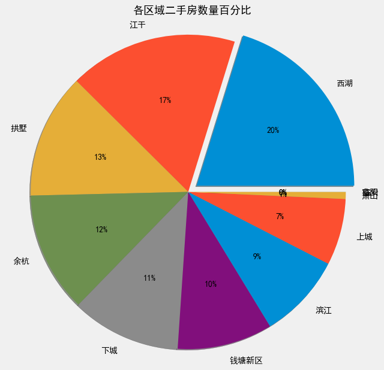

```python
df_house_count = data.groupby('houseRegion')['houseCode'].count().sort_values(ascending=False)
df_house_count.columns = ['Region', 'Count']

plt.figure(figsize=(10,10))
plt.title(u'各区域二手房数量百分比', fontsize=18)
explode=[0]*len(df_house_count)
explode[0] = 0.2
plt.pie(df_house_count, radius=3, autopct='%1.f%%', shadow=True, labels=df_house_count.index, explode=explode)
plt.axis('equal')

plt.show()
```

### 2.1.2 根据二手房区域分组对比二手房数量和每平米房价

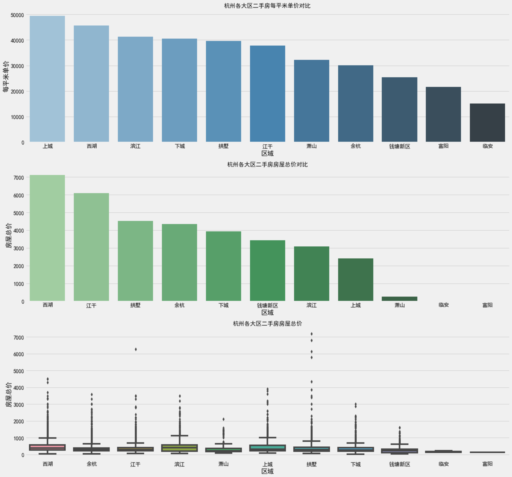

```python
df_house_count = df.groupby('houseRegion')['houseAllPrice'].count().sort_values(ascending=False).to_frame().reset_index()
df_house_mean = df.groupby('houseRegion')['houseUnitPrice'].mean().sort_values(ascending=False).to_frame().reset_index()

f, [ax1,ax2,ax3] = plt.subplots(3,1,figsize=(20,20))
sns.barplot(x='houseRegion', y='houseUnitPrice', palette="Blues_d", data=df_house_mean, ax=ax1)
ax1.set_title('杭州各大区二手房每平米单价对比',fontsize=15)
ax1.set_xlabel('区域')
ax1.set_ylabel('每平米单价')

sns.barplot(x='houseRegion', y='houseAllPrice', palette="Greens_d", data=df_house_count, ax=ax2)
ax2.set_title('杭州各大区二手房房屋总价对比',fontsize=15)
ax2.set_xlabel('区域')
ax2.set_ylabel('房屋总价')

sns.boxplot(x='houseRegion', y='houseAllPrice', data=df, ax=ax3)
ax3.set_title('杭州各大区二手房房屋总价',fontsize=15)
ax3.set_xlabel('区域')
ax3.set_ylabel('房屋总价')
```

二手房均价：上城区的房价最贵均价大约5万/平，然后是西湖区大约4.5万/平，滨江、下城、拱墅等相差不大，临安最低，可能是属于郊区的缘故。

二手房总价：通过箱型图看到，各大区域房屋总价中位数都都在1000万以下，且房屋总价离散值较高，拱墅最高达到了7000万，说明房屋价格特征不是理想的正太分布。

### 2.2 分析二手房面积和出售价格的关系

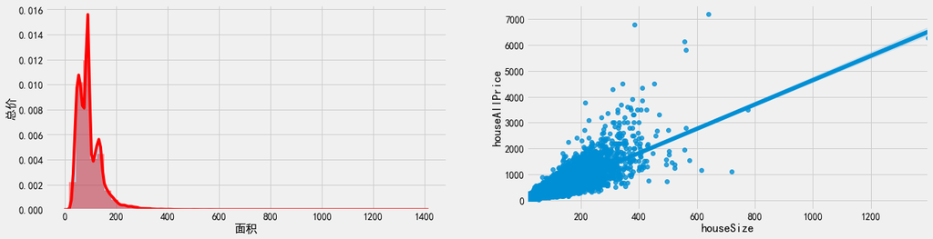

```python
f, [ax1,ax2] = plt.subplots(1, 2, figsize=(20, 5))
# 建房面积的分布情况
sns.distplot(data['houseSize'], bins=50, ax=ax1, color='r')
sns.kdeplot(data['houseSize'],shade=True, ax=ax1)
# 建房面积和出售价格的关系
sns.regplot(x='houseSize', y='houseAllPrice', data=data, ax=ax2)
ax1.set_xlabel('面积')
ax1.set_ylabel('总价')
plt.show()
```

由从左到右第一幅图可以看出 基本二手房面积在60-200平方米之间，其中一百平方米左右的占比更大。由第二幅看出，二手房总价与二手房面积基本成正比，和我们的常识吻合。

### 2.3 分析二手房朝向分布频率

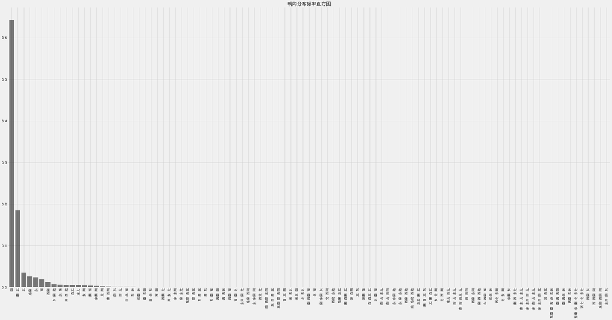

```python
cx_g = data['houseDirection'].value_counts(sort = True)
r_cx =  pd.DataFrame(cx_g)

r_cx.rename(columns = {cx_g.name:'频数'},inplace=True)
r_cx['频率'] = r_cx['频数'] / r_cx['频数'].sum()

plt.figure(num=1,figsize=(40,20))
r_cx['频率'].plot(kind='bar',width=0.8,rot=0,color='k',grid=True,alpha=0.5)
plt.xticks(rotation=90)
plt.title("朝向分布频率直方图")
plt.show()
```

可以看出，本地的二手房朝向大多以南为主，人们在挑选房子时，经常喜欢挑坐北朝南的房子，因为这种房子采光好，顺光顺水，冬暖夏凉，很适合人居住。

### 2.4 分析各户型占比数量

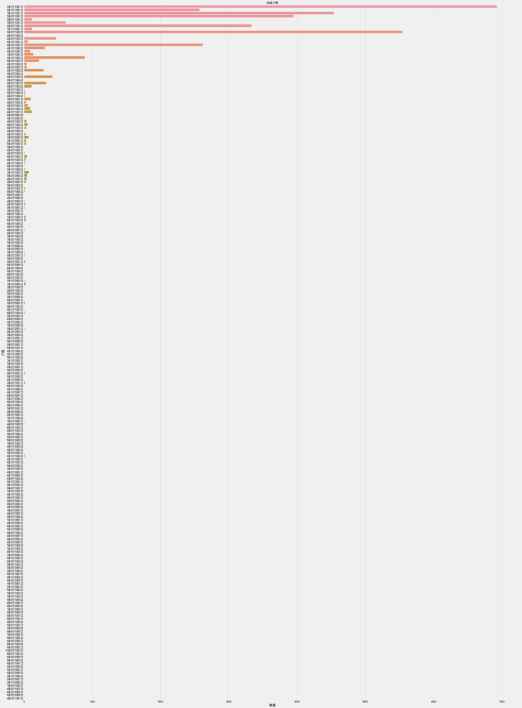

```python
f, ax1= plt.subplots(figsize=(40,60))
sns.countplot(y='houseType', data=data, ax=ax1)
ax1.set_title('房屋户型',fontsize=15)
ax1.set_xlabel('数量')
ax1.set_ylabel('户型')
plt.show()
```

### 2.5 分析二手房装修类型与数量、价格的关系

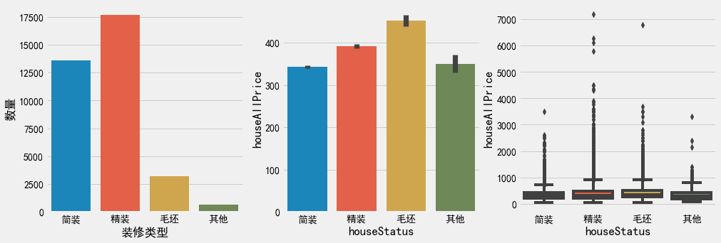

```python
f, [ax1,ax2,ax3] = plt.subplots(1, 3, figsize=(15, 5))
sns.countplot(data['houseStatus'], ax=ax1)
ax1.set_xlabel('装修类型')
ax1.set_ylabel('数量')
sns.barplot(x='houseStatus', y='houseAllPrice', data=data, ax=ax2)
sns.boxplot(x='houseStatus', y='houseAllPrice', data=data, ax=ax3)
plt.show()
```

观察到，精装修的二手房数量最多，简装其次，也是我们平日常见的。而对于价格来说，毛坯类型却是最高，其次是精装修。

### 2.6 分析二手房楼层与房价、数量的关系

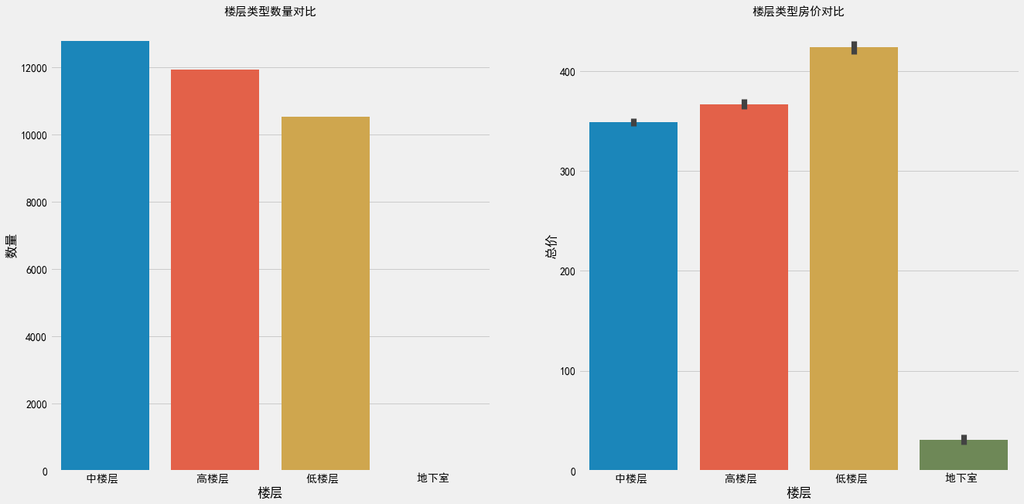

```python
df['floor']=df['houseFloor'].map(lambda x:x.split('(')[0])
f, [ax1,ax2] = plt.subplots(1, 2, figsize=(20,10))
sns.countplot(x='floor', data=df, ax=ax1)
ax1.set_title('楼层类型数量对比',fontsize=15)
ax1.set_xlabel('楼层')
ax1.set_ylabel('数量')

sns.barplot(x='floor', y='houseAllPrice', data=df, ax=ax2)
ax2.set_title('楼层类型房价对比',fontsize=15)
ax2.set_xlabel('楼层')
ax2.set_ylabel('总价')
plt.show()
```

二手房楼层类型为中楼层居多，其次是高楼层，地下室甚至非常罕见。但是总房价却是低楼层类型更高，结果也符合实际，因为低楼层不管是回家还是外出都比较方便；地下室房价特别便宜，但是数量太少。

### 2.7 分析有无电梯与房价、数量的关系

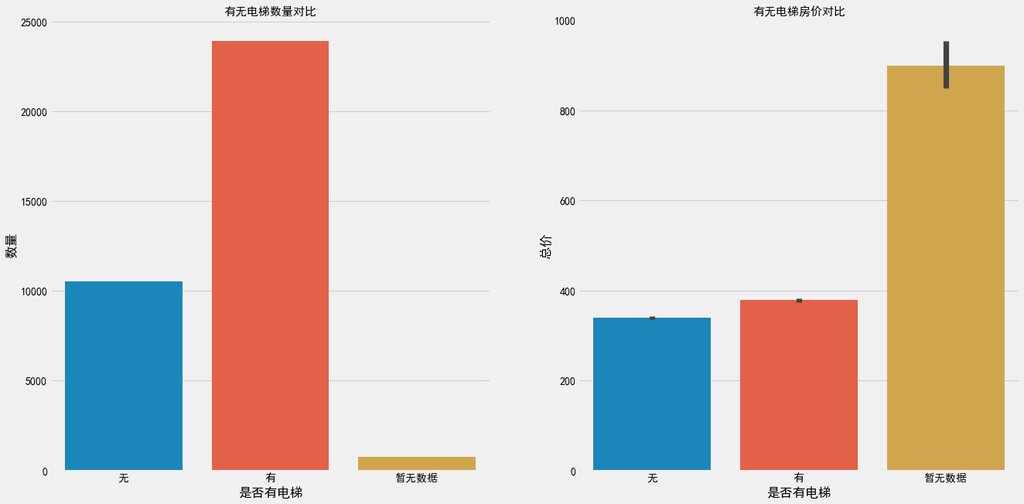

```python
f, [ax1,ax2] = plt.subplots(1, 2, figsize=(20, 10))
sns.countplot(data['houseElevator'], ax=ax1)
ax1.set_title('有无电梯数量对比',fontsize=15)
ax1.set_xlabel('是否有电梯')
ax1.set_ylabel('数量')

sns.barplot(x='houseElevator', y='houseAllPrice', data=data, ax=ax2)
ax2.set_title('有无电梯房价对比',fontsize=15)
ax2.set_xlabel('是否有电梯')
ax2.set_ylabel('总价')
plt.show()
```

有电梯的二手房占大多数，但是房价也相对更高。

### 2.8 分析在不同装修类型和电梯情况下，二手房年份和总价的分布情况

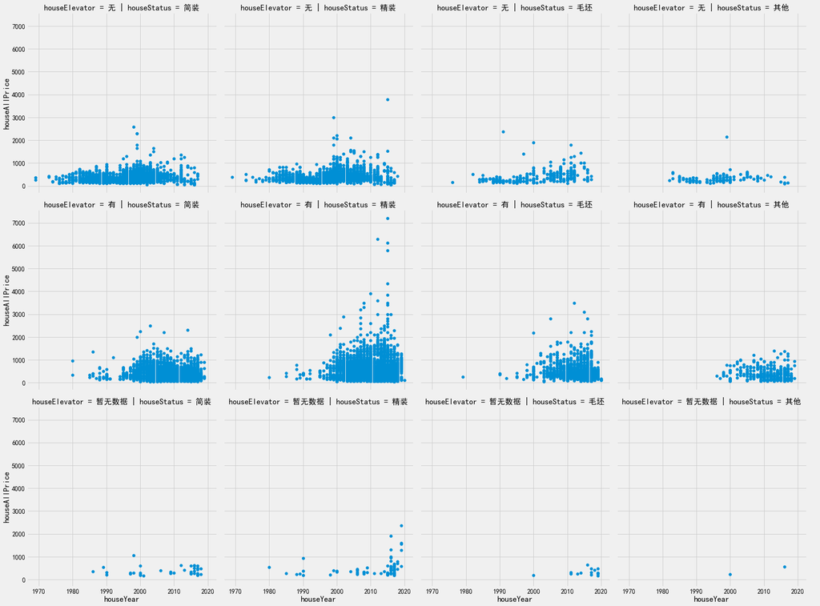

```python
# 年份 装修 价格分析
grid = sns.FacetGrid(df, row='houseElevator', col='houseStatus', palette='seismic',size=6)
grid.map(plt.scatter, 'houseYear', 'houseAllPrice')
grid.add_legend()
```

可以看出，本地大部分精装并且有电梯的二手房，年份都不太久远，但是房价也普遍较高。

### 2.9 分析交通是否便利与数量、房价的关系

从houseAddress描述房子信息中提取关键词。若带有“地铁”，则认为其交通方便，否则交通不便。

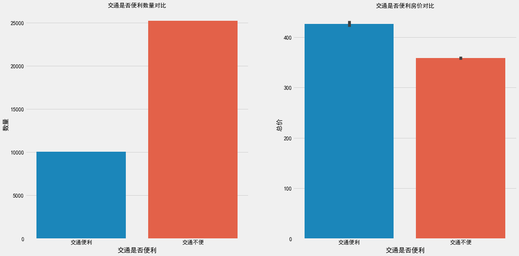

```python
df['houseAddress']=df['houseAddress'].apply(lambda x:str(x))
df['trafic']=df['houseAddress'].apply(lambda x:'交通便利' if x.find("地铁")>=0 else "交通不便"  )

f, [ax1,ax2] = plt.subplots(1, 2, figsize=(20, 10))
sns.countplot(df['trafic'], ax=ax1)
ax1.set_title('交通是否便利数量对比',fontsize=15)
ax1.set_xlabel('交通是否便利')
ax1.set_ylabel('数量')
sns.barplot(x='trafic', y='houseAllPrice', data=df, ax=ax2)
ax2.set_title('交通是否便利房价对比',fontsize=15)
ax2.set_xlabel('交通是否便利')
ax2.set_ylabel('总价')

plt.show()
```

可以看出，本地二手房交通不便的占大多数，并且交通便利的二手房房价也会相对较高。

## 三、房价预测

机器学习需要输入好的数据集，有意义的特征字段才能使得结果更加准确。

杭州二手房房价预测项目中的数据集的特征有：

- houseSize：房屋面积，平方米
- houseYear: 房屋建造时间，年
- houseElevator: 是否有电梯
- houseStatus: 是否是精装修，或者简装
- houseRegion：杭州的区域

目标变量：

- houseAllPrice: 房屋人民币售价，万

### 3.1 数据清洗

可以看到，数据集中的数据类型有文本，类目，数值等。由于需要将数据集作为输入给机器学习模型计算，而数据类型统一为数值型才能计算，因此将数据类型全部转换为数值类型，以很好的为机器学习模型服务。

```python
# 完善数据集，删除无意义特征，将特征数字化
drop_out = ['houseCode', 'houseName', 'houseDirection', 'houseType','houseAddress','houseDistrict',
            'houseFloor','Latitude','Longitude','houseUnitPrice']
data = data.drop(drop_out, axis=1)
data.dropna(axis = 0, subset = ['houseAllPrice','houseYear','houseStatus'], inplace=True)

data.loc[data['houseElevator']=='暂无数据','houseElevator'] ='无'
data['houseElevator'].fillna(value = "无")
print(data['houseElevator'].value_counts())
data.isnull().any()
```

```
有    22892
无    10885
Name: houseElevator, dtype: int64
```

```
houseElevator    False
houseRegion      False
houseSize        False
houseStatus      False
houseAllPrice    False
houseYear        False
dtype: bool
```

```python
# 汉字到数字的映射字典
loc_map = {'上城':1, '西湖':2, '滨江':3, '下城':4, '拱墅':5, '江干':6, '萧山':7, '余杭':8, '钱塘新区':9, '富阳':10, '临安':11}
renovation_map = {'简装':0, '精装':1, '其他':2, '毛坯':3}
elevator_map = {'有':1, '无':0}

data['houseRegion'] = data['houseRegion'].map(loc_map)
data['houseStatus'] = data['houseStatus'].map(renovation_map)
data['houseElevator'] = data['houseElevator'].map(elevator_map)
print('杭州二手房房价有数据 {0} 条，字段 {1} 个。'.format(*data.shape))
# 分配数据集-训练集和测试集
prices = data['houseAllPrice']
features = data.drop('houseAllPrice', axis = 1)
# 将连续数值型特征 Year 离散化，做分箱处理，pandas的 qcut 按中位数对“Year”特征进行分箱，分割数为8等份
data['houseYear'] = pd.qcut(data['houseYear'],8).astype('object')
data.head(10)
```

```
杭州二手房房价有数据 33777 条，字段 6 个。
```

|  | houseElevator | houseRegion | houseSize | houseStatus | houseAllPrice | houseYear |
| --- | --- | --- | --- | --- | --- | --- |
| 0 | 0 | 2 | 50.38 | 0 | 218.0 | (1968.999, 1996.0] |
| 1 | 0 | 2 | 60.28 | 1 | 249.0 | (1968.999, 1996.0] |
| 2 | 0 | 2 | 41.09 | 0 | 168.0 | (1968.999, 1996.0] |
| 3 | 1 | 2 | 87.59 | 0 | 360.0 | (2011.0, 2014.0] |
| 4 | 0 | 2 | 98.00 | 1 | 440.0 | (2000.0, 2005.0] |
| 5 | 0 | 2 | 44.68 | 0 | 190.0 | (1968.999, 1996.0] |
| 6 | 1 | 2 | 73.97 | 0 | 280.0 | (1996.0, 2000.0] |
| 7 | 0 | 2 | 51.89 | 0 | 215.0 | (1968.999, 1996.0] |
| 8 | 0 | 2 | 71.27 | 0 | 278.0 | (1968.999, 1996.0] |
| 9 | 0 | 2 | 48.86 | 0 | 205.0 | (1968.999, 1996.0] |

### 3.2 数据划分和建立模型

- 数据划分 将数据集划分为训练集与测试集。
- 建立模型 特征工程包括的内容很多，有特征清洗，预处理，监控等，而预处理根据单一特征或多特征又分很多种方法，如归一化，降维，特征选择，特征筛选等等 使用Cart决策树的回归模型对二手房房价进行分析预测 使用交叉验证方法充分利用数据集进行训练，避免数据划分不均匀的影响。 使用GridSearchCV方法优化模型参数 使用R2评分方法对模型预测评分

```python
import numpy as np

# 转换训练测试集格式为数组
features = np.array(features)
prices = np.array(prices)

# 导入sklearn进行训练测试集划分
from sklearn.model_selection import train_test_split
features_train, features_test, prices_train, prices_test = train_test_split(features, prices, test_size=0.2, random_state=0)

from sklearn.model_selection import KFold
from sklearn.tree import DecisionTreeRegressor
from sklearn.metrics import make_scorer
from sklearn.model_selection import GridSearchCV

# 利用GridSearchCV计算最优解
def fit_model(X, y):
    """ 基于输入数据 [X,y]，利于网格搜索找到最优的决策树模型"""

    cross_validator = KFold(10, shuffle=True)

    regressor = DecisionTreeRegressor()

    params = {'max_depth':[1,2,3,4,5,6,7,8,9,10]}

    scoring_fnc = make_scorer(performance_metric)

    grid = GridSearchCV(estimator = regressor, param_grid = params, scoring = scoring_fnc, cv = cross_validator)

    # 基于输入数据 [X,y]，进行网格搜索
    grid = grid.fit(X, y)
    return grid.best_estimator_

# 计算R2分数
def performance_metric(y_true, y_predict):
    """计算并返回预测值相比于预测值的分数"""
    from sklearn.metrics import r2_score
    score = r2_score(y_true, y_predict)

    return score
```

### 3.3 调参优化模型

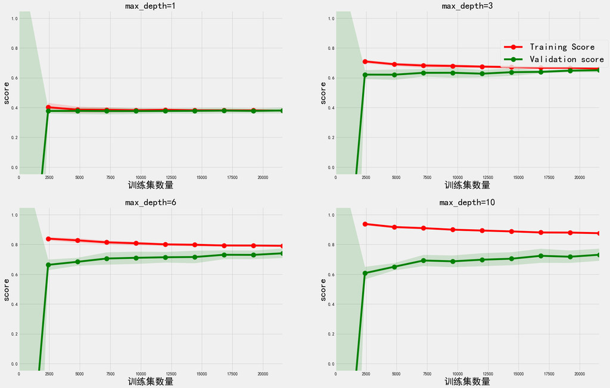

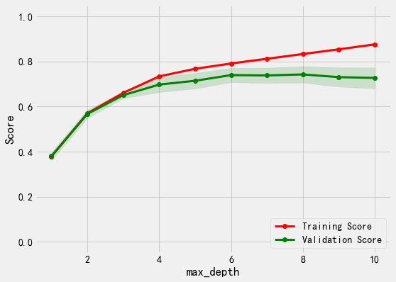

```python
# 可视化模拟学习曲线，观察是否出现过拟合问题。
from sklearn.model_selection import learning_curve, validation_curve
from sklearn.model_selection import ShuffleSplit

#绘制Learning_curve曲线
def ModelLearning(X, y):
    cv = ShuffleSplit(n_splits=10, test_size=0.2, random_state=0)
    train_sizes = np.rint(np.linspace(1, X.shape[0]*0.8-1, 10)).astype(int)
    #print(train_sizes)

    fig = plt.figure(figsize=(30,20))

    for k, depth in enumerate([1,3,6,10]):
        regressor = DecisionTreeRegressor(max_depth=depth)

        sizes, train_scores, test_scores = learning_curve(regressor, X, y, cv=cv, train_sizes=train_sizes)

        train_std = np.std(train_scores, axis=1)
        train_mean = np.mean(train_scores, axis=1)
        valid_std = np.std(test_scores, axis=1)
        valid_mean = np.mean(test_scores, axis=1)

        ax = fig.add_subplot(2, 2, k+1)
        ax.plot(sizes, train_mean, 'o-', color='r', linewidth=6, markersize=15, label='Training Score')
        ax.plot(sizes, valid_mean, 'o-', color='g', linewidth=6, markersize=15, label='Validation score')
        ax.fill_between(sizes, train_mean - train_std, train_mean + train_std, alpha=0.15, color='r')
        ax.fill_between(sizes, valid_mean - valid_std, valid_mean + valid_std, alpha=0.15, color='g')

        ax.set_title('max_depth={}'.format(depth), fontsize=30)
        ax.set_xlabel('训练集数量', fontsize=30)
        ax.set_ylabel('score', fontsize=30)
        ax.set_xlim([0, X.shape[0]*0.8])
        ax.set_ylim([-0.05, 1.05])

    ax.legend(bbox_to_anchor=(1.05,2.05), loc='upper right', fontsize=30)
    fig.show()

#绘制Validation_curve曲线
def ModelComplexity(X, y):
    cv = ShuffleSplit(n_splits=10, test_size=0.2, random_state=0)
    max_depth = np.arange(1,11)

    train_scores, valid_scores = validation_curve(DecisionTreeRegressor(), X, y, param_name='max_depth', param_range=max_depth, cv=cv)

    train_std = np.std(train_scores, axis=1)
    train_mean = np.mean(train_scores, axis=1)
    valid_std = np.std(valid_scores, axis=1)
    valid_mean = np.mean(valid_scores, axis=1)

    plt.figure(figsize=(8,6))
    plt.plot(max_depth, train_mean, 'o-', color='r', label='Training Score', linewidth=3, markersize=6)
    plt.plot(max_depth, valid_mean, 'o-', color='g', label='Validation Score', linewidth=3, markersize=6)
    plt.fill_between(max_depth, train_mean - train_std, train_mean + train_std, alpha=0.15, color='r')
    plt.fill_between(max_depth, valid_mean - valid_std, valid_mean + valid_std, alpha=0.15, color='g')

    plt.legend(loc='lower right')
    plt.xlabel('max_depth')
    plt.ylabel('Score')
    plt.ylim([-0.05, 1.05])
    plt.show()

ModelLearning(features_train, prices_train)
ModelComplexity(features_train, prices_train)
```

```python
optimal_reg1 = fit_model(features_train, prices_train)

# 输出最优模型的 'max_depth' 参数
print("最理想模型的参数 'max_depth' 是 {} 。".format(optimal_reg1.get_params()['max_depth']))

predicted_value = optimal_reg1.predict(features_test)
r2 = performance_metric(prices_test, predicted_value)

fit_model(features, prices)
print("最优模型在测试数据上 R^2 分数 {:,.2f}。".format(r2))
```

```
最理想模型的参数 'max_depth' 是 8 。
最优模型在测试数据上 R^2 分数 0.72。
```

```python
dt = DecisionTreeRegressor(max_depth=8,random_state=25)
dt=dt.fit(features_train,prices_train)
print(f'训练集得分：{round(dt.score(features_train,prices_train),2)}')
print(f'测试集得分：{round(dt.score(features_test,prices_test),2)}')
```

```
训练集得分：0.83
测试集得分：0.72
```

### 3.4 实例测试

小明一家需要购房，假设要求如下：

```python
apply = np.array([105,1,1,1,10]).reshape(1,-1)
print('------------预测结果-------------')
print(f'共需要：{round(dt.predict(apply)[0],2)}万元')
```

```
------------预测结果-------------
共需要：114.05万元
```